# Assignment 9 - K-means

Author

Madelyn Willis

# 1 Goal of this assignment

The goal of this assignment is for you to **explore the k-means algorithm** learned in class.

In specific, you will be asked to:  
- Use a different number of k than what we did in class,  
- Validate the results of the new model, and  
- Compare your results with those found in class

# 2 Instructions

You will first need to watch (and code along with) the following k-means video:

- k-means lab: https://youtu.be/GFgMp5tYiMU?si=CI0E-2r-cYZLGVL1 (start from beginning of video, watch till the 01:10)
- The partial script for the video above is in our GitHub repository, 04-classcode, **03-25_multivar_kmeans_partial.qmd**. Move the script mentioned above into the `code` subfolder of your `10_multivar` project

**AFTER watching the video and developing the code in class**, then start working on this HW assignment (instructions below):

- Move this script into the `code` subfolder of your `10_multivar` project
- On this script, fill your name under the `title` section of the YAML
- Go back to the class k-means script, choose a different number of k than what we did in class, and run it.

# 3 Questions

## 3.1 1. What number of k did you select? Why?

**I chose 3. On the total error plot, the biggest change in slope, or the elbow, would be at k = 3.**

## 3.2 2. How many observations are there in each cluster?

**253, 337, and 108.**

## 3.3 3. Using the `fviz_cluster()` function, import here the original plot with k=4 did in class, and the new one with the number of k you selected for this exercise. How do they visually compare? Which one seems to be a better choice, and why?

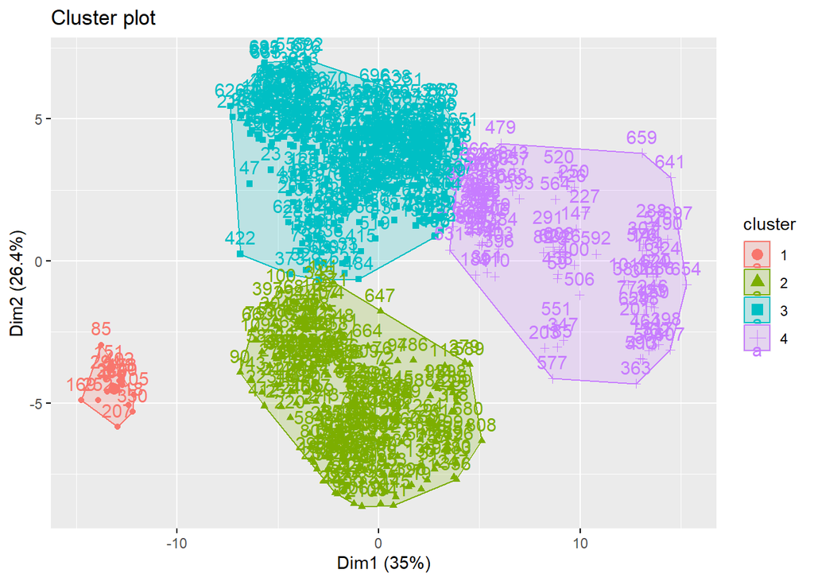

```r
library(tidyverse)

library(factoextra)

weather <- read_csv("../data/weather_monthsum.csv") %>%
  dplyr::select(-c(year:strength_gtex)) %>%
  mutate(across(everything(), ~scale(.x)))

mod_km4 <- kmeans(weather,
                  centers = 4,
                  nstart = 10)
mod_km3 <- kmeans(weather,
                  centers = 3,
                  nstart = 10)

fviz_cluster(mod_km4,
             data = weather)
```

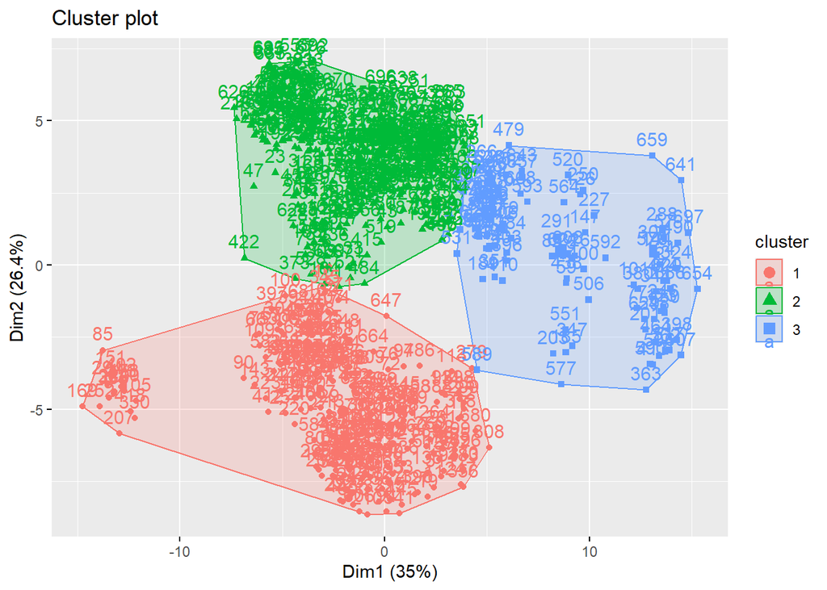

```r
fviz_cluster(mod_km3,
             data = weather)
```

**Since I chose k = 3, there will be one less cluster than k = 4. This can be seen visually, as the cluster in the lower left in k = 4 is now absorbed by the lower center cluster in k = 4. Interestingly, though, observation 589 is clustered with the top right cluster in k = 3, but in k = 4 it is a part of the lower center cluster.**

**I believe that the k = 4 cluster is better, since all the clusters have a more rounded/ circular shape. In k = 3, the lower center cluster is very oblong, and there is a large gap in between what would two separate clusters in k = 4.**

# 4 Submitting your work

Once you have developed all the code and answers, make sure to Render this quarto file.

**Notes on rendering**:

- Make sure to render your work and inspect how the final html look like.
- If it does not look professional for whatever reason, then fix the issue, re-render it, recheck.
- Only send me your work once your html file looks professional.
  - **DO NOT** delete the file’s heading levels (# and ##). They set up the proper heading 1 and 2 levels, and I use them to guide my grading.
  - If a given chunk is also outputting warnings or messages, inhibit this behavior by changing the chunk options `message` and `warning` to `FALSE` (I’ll demo this in a moment).
  - If, after rendered, 2 lines of text are connected and you wish to “break line” between them, add 2 extra spaces after the first one (I’lld demo this in a moment).

After rendering, an .html file will be created on your `code` folder.

Rename this file to `Assignment-09-kmeans-LASTNAME.html`.

For ex., mine would be `Assignment-09-kmeans-Bastos.html`.

Submit your work by uploading the **html** file to **eLC Assignment #9 - K-means** by April 3rd 11:59 pm.